# Mixed ANOVA + Pairwise Comparison

5/7/2021

# Description

**Source of motivation: [Mixed ANOVA in R](https://www.datanovia.com/en/lessons/mixed-anova-in-r)** **Adapted from Ruslan Klymentiev RAnovas_main.R for the same project**

## Assumptions Check

**Outliers**. Values above `Q3 + 1.5xIQR` or below `Q1 - 1.5xIQR` are considered as outliers. Values above `Q3 + 3xIQR` or below `Q1 - 3xIQR` are considered as extreme points (or extreme outliers). Observations that are considered as extreme points are marked red.

**Normality Assumptions**. Plot shows Q-Q plot for subsets of data. If points lie on the line, we can assume that data is fairly symmetrical (and that’s what we want).

**Homogeneity of Variance Assumption**. Performed using [Levene’s test](https://en.wikipedia.org/wiki/Levene%27s_test).

$H_0$: the groups have equal population variances $H_A$: the groups don’t have equal population variances Observations with p-value < 0.05 are marked red, since they may violate the ANOVA results.

## Mixed ANOVA

“*In statistics, a mixed-design analysis of variance model, also known as a split-plot ANOVA, is used to test for differences between two or more independent groups whilst subjecting participants to repeated measures.*” ([Wikipedia](https://en.wikipedia.org/wiki/Mixed-design_analysis_of_variance))

within subjects group (with repeated measures): `Measurement` between subjects group: `Group`

## Post-hoc Tests

**Significant two-way interaction**. Can be used if an interaction term in Mixed ANOVA results showed significance. In other words, impact of `Group` on the outcome variable (`VectorStrength`) depends on the `Measurement` (and vice versa)

**Effect of `Group` at each `Measurement`**. Shows the **simple main effect** of the `Group`

**Pairwise comparisons between `Group`**. Performs [Welch’s t-tests](https://en.wikipedia.org/wiki/Welch%27s_t-test) (for unequal variances) for comparing `Group` for each `Measurement`

**Effect of `Measurement` at each level of `Group`**. Shows the **simple main effect** of the **`Measurement`**

**Pairwise comparisons between `Measurement`**. Performs **paired** two-sample t-test for comparing `Measurement` for each `Group`.

**Non-significant two-way interaction**. Shows the **main effect** for `Group` and `Measurement`. Used if there was non-significant two-way interaction.

For each table observations with adjusted p-value (using Bonferroni correction) which is less then 0.05 are marked green.

```r
library(tidyverse)
library(ggpubr)
library(rstatix)
library(knitr)
library(kableExtra)
```

```r
raw_data <- read_csv("D:/DynamicCSDjl/Data/VSoutput/CL_5_VectorStrength_Stats.csv")
data_type <- "CL"

layers <- unique(raw_data$Layer)
stimfreq <- 5
metrics <- c("VectorStrenght")

red_color <- "#ffb3b3"
green_color <- "#d6f5d6"

# values for testing
freq <- 5
layer <- "All"
metric <- "VectorStrenght"
```

# Results

```r
for (layer in layers){
  # for (layer in c("All", "I_II")){
  cat("###", layer, " Layer {.tabset .tabset-fade .tabset-pills}\n")

  model_data <- raw_data %>%
    filter(
      Layer == layer)

  model_data <- model_data %>%
    select(Group, Animal, Measurement, VectorStrenght)

  if(grepl("CL", data_type)) {
    model_data <- model_data %>%
      convert_as_factor(Group, Animal, Measurement) %>%
      reorder_levels(
        Measurement,
        order = c("preCL_1", "CL_1", "CL_2", "CL_3", "CL_4"))
  } else {
    model_data <- model_data %>%
      filter(Measurement != "AM_5") %>%
      reorder_levels(
        Measurement,
        order = c("preAM_1", "AM_1", "AM_2", "AM_3", "AM_4"))
  }

  cat("####", metric, "{.tabset .tabset-fade .tabset-pills}\n")

  cat("##### Assumptions Check\n")

  cat("<b>===OUTLIERS===</b>\n\n")

  df <- model_data %>%
    group_by(Measurement, Group) %>%
    identify_outliers(eval(metric))

  if(nrow(df) > 0){
    df %>%
      kable(escape = F, digits = 6) %>%
      kable_classic_2(full_width = F) %>%
      kable_styling() %>%
      row_spec(
        which(df$is.extreme == TRUE), bold = T,
        background = red_color) %>%
      print()
  } else{
    cat("\n\nNo outliers were detected.\n\n")
  }

  cat("\n\n<b>===NORMALITY ASSUMPTION===</b>\n\n")

  p <- ggqqplot(model_data, metric, ggtheme = theme_bw()) +
    facet_grid(Measurement ~ Group)
  plot(p)

  cat("\n\n<b>===HOMOGENEITY OF VARIANCE ASSUMPTION===</b>\n\n")

  df <- model_data %>%
    group_by(Measurement) %>%
    levene_test(formula = as.formula(paste0(metric, "~ Group")))

  df %>%
    kable(escape = F, digits = 3) %>%
    kable_classic_2(full_width = F) %>%
    kable_styling() %>%
    row_spec(
      which(df$p <= 0.05), bold = T,
      background = red_color) %>%
    print()

  cat('\n\n')

  cat("##### Mixed ANOVA\n")

  # Two-way mixed ANOVA test
  res.aov <- anova_test(
    data = model_data, dv = eval(metric), wid = Animal,
    between = Group, within = Measurement)

  df <- get_anova_table(res.aov) %>%
    data.frame()

  df %>%
    kable(escape = F) %>%
    kable_classic_2(full_width = F) %>%
    kable_styling() %>%
    row_spec(
      which(df$p <= 0.05), bold = T,
      background = green_color) %>%
    print()

  cat('\n\n')

  cat("##### Post-hoc Tests\n")

  cat("\n\n<b>===SIGNIFICANT TWO-WAY INTERACTION===</b>\n\n")

  cat("\n\n\n<b>=EFFECT OF GROUP AT EACH MEASUREMENT=</b>\n\n")

  one.way <- model_data %>%
    group_by(Measurement) %>%
    anova_test(dv = eval(metric), wid = Animal, between = Group) %>%
    get_anova_table() %>%
    adjust_pvalue(method = "bonferroni")

  df <- one.way %>%
    data.frame() %>%
    select(-F)
  df %>%
    kable(escape = F) %>%
    kable_classic_2(full_width = F) %>%
    kable_styling() %>%
    row_spec(
      which(df$p.adj <= 0.05), bold = T,
      background = green_color) %>%
    print()

  cat("\n\n\n<b>=PAIRWISE COMPARISONS BETWEEN GROUP LEVELS=</b>\n\n")

  pwc <- model_data %>%
    group_by(Measurement) %>%
    pairwise_t_test(
      as.formula(paste0(metric, "~ Group")),
      p.adjust.method = "bonferroni",
      pool.sd = FALSE,
      var.equal = FALSE)

  eff_size <- model_data %>%
    group_by(Measurement) %>%
    cohens_d(
      as.formula(paste0(metric, "~ Group")),
      var.equal = FALSE)

  df <- pwc %>%
    left_join(eff_size) %>%
    data.frame()

  df %>%
    kable(escape = F, digits = 3) %>%
    kable_classic_2(full_width = F) %>%
    kable_styling() %>%
    row_spec(
      which(df$p.adj <= 0.05), bold = T,
      background = green_color) %>%
    print()

  cat("\n\n\n<b>=EFFECT OF MEASUREMENT AT EACH LEVEL OF GROUP=</b>\n\n")

  one.way2 <- model_data %>%
    group_by(Group) %>%
    anova_test(dv = eval(metric), wid = Animal, within = Measurement) %>%
    get_anova_table() %>%
    adjust_pvalue(method = "bonferroni")

  df <- one.way2 %>%
    data.frame()
  df %>%
    kable(escape = F) %>%
    kable_classic_2(full_width = F) %>%
    kable_styling() %>%
    row_spec(
      which(df$p.adj <= 0.05), bold = T,
      background = green_color) %>%
    print()

  cat("\n\n\n<b>=PAIRWISE COMPARISONS BETWEEN MEASUREMENTS AT EACH GROUP LEVELS=</b>\n\n")

  exclude_animals <- model_data %>%
    group_by(Animal) %>%
    summarise(n = n_distinct(Measurement)) %>%
    filter(n < 5) %>%
    pull(Animal)

  pwc2 <- model_data %>%
    filter(!(Animal %in% exclude_animals)) %>%
    group_by(Group) %>%
    pairwise_t_test(
      as.formula(paste0(metric, "~ Measurement")),
      paired = TRUE,
      pool.sd = FALSE,
      var.equal = FALSE,
      p.adjust.method = "bonferroni"
    )

  eff_size2 <- model_data %>%
    filter(!(Animal %in% exclude_animals)) %>%
    group_by(Group) %>%
    cohens_d(
      as.formula(paste0(metric, "~ Measurement")),
      paired = TRUE,
      var.equal = FALSE)

  df <- pwc2 %>%
    left_join(eff_size2) %>%
    data.frame()
  df %>%
    kable(escape = F, digits = 3) %>%
    kable_classic_2(full_width = F) %>%
    kable_styling() %>%
    row_spec(
      which(df$p.adj <= 0.05), bold = T,
      background = green_color) %>%
    print()

  cat("\n\n\n<b>===NON-SIGNIFICANT TWO-WAY INTERACTION===</b>\n\n")
  cat("\n\n\n<b>=MAIN EFFECT OF MEASUREMENT=</b>\n\n")

  df <- model_data %>%
    filter(!(Animal %in% exclude_animals)) %>%
    pairwise_t_test(
      as.formula(paste0(metric, "~ Measurement")),
      paired = TRUE,
      p.adjust.method = "bonferroni"
    ) %>%
    data.frame()

  df %>%
    kable(escape = F) %>%
    kable_classic_2(full_width = F) %>%
    kable_styling() %>%
    row_spec(
      which(df$p.adj <= 0.05), bold = T,
      background = green_color) %>%
    print()

  cat("\n\n\n<b>=MAIN EFFECT OF GROUP=</b>\n\n")

  df <- model_data %>%
    pairwise_t_test(
      as.formula(paste0(metric, "~ Group")),
      p.adjust.method = "bonferroni"
    ) %>%
    data.frame()

  df %>%
    kable(escape = F) %>%
    kable_classic_2(full_width = F) %>%
    kable_styling() %>%
    row_spec(
      which(df$p.adj <= 0.05), bold = T,
      background = green_color) %>%
    print()

  cat('\n\n')

  cat("##### Plots\n")

  pwc <- pwc %>% add_xy_position(x = "Measurement")
  pwc2 <- pwc2 %>% add_xy_position(x = "Group")

  box_plot <- ggboxplot(
    model_data, x = "Measurement", y = metric,
    color = "Group", palette = "jco"
  )

  box_plot2 <- ggboxplot(
    model_data, x = "Group", y = metric,
    color = "Measurement", palette = "jco"
  )

  p <- box_plot +
    stat_pvalue_manual(pwc, tip.length = 0.01, hide.ns = TRUE) +
    labs(
      title = paste0(metric, " for ", layer, " Layer, ", freq, "Hz and 1st Click"),
      subtitle = get_test_label(res.aov, detailed = TRUE),
      caption = get_pwc_label(pwc)
    )

  plot(p)

  cat('\n\n')

  p <- box_plot2 +
    stat_pvalue_manual(pwc2, tip.length = 0.01, hide.ns = TRUE) +
    labs(
      title = paste0(metric, " for ", layer, " Layer, ", freq, "Hz and 1st Click"),
      subtitle = get_test_label(res.aov, detailed = TRUE),
      caption = get_pwc_label(pwc2)
    )

  plot(p)

  cat('\n\n')
}
```

### All Layer

#### VectorStrenght

##### Assumptions Check

**===OUTLIERS===**

| Group | Measurement | Animal | VectorStrenght | is.outlier | is.extreme |
| --- | --- | --- | --- | --- | --- |
| KIC | preCL_1 | KIC12 | 0.752382 | TRUE | FALSE |
| KIV | preCL_1 | KIV12 | 0.987941 | TRUE | TRUE |
| KIV | CL_1 | KIV12 | 0.983240 | TRUE | TRUE |
| KIV | CL_2 | KIV12 | 0.984028 | TRUE | FALSE |
| KIV | CL_3 | KIV12 | 0.992724 | TRUE | FALSE |
| KIV | CL_4 | KIV03 | 0.727625 | TRUE | FALSE |
| KIV | CL_4 | KIV12 | 0.936286 | TRUE | TRUE |

**===NORMALITY ASSUMPTION===**

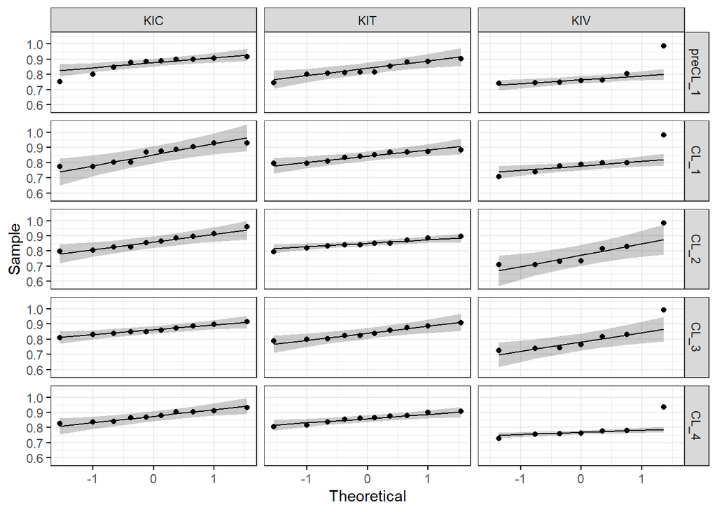

**===HOMOGENEITY OF VARIANCE ASSUMPTION===**

| Measurement | df1 | df2 | statistic | p |
| --- | --- | --- | --- | --- |
| preCL_1 | 2 | 24 | 0.097 | 0.908 |
| CL_1 | 2 | 24 | 0.970 | 0.393 |
| CL_2 | 2 | 24 | 1.757 | 0.194 |
| CL_3 | 2 | 24 | 1.577 | 0.227 |
| CL_4 | 2 | 24 | 0.151 | 0.861 |

##### Mixed ANOVA

Effect

DFn

DFd

F

p

p..05

ges

Group

2.00

24.00

3.982

0.032

0.212

Measurement

2.61

62.72

0.462

0.684

0.004

Group:Measurement

5.23

62.72

0.930

0.471

0.014

##### Post-hoc Tests

**===SIGNIFICANT TWO-WAY INTERACTION===**

**=EFFECT OF GROUP AT EACH MEASUREMENT=**

Measurement

Effect

DFn

DFd

p

p..05

ges

p.adj

preCL_1

Group

2

24

0.067

0.202

0.335

CL_1

Group

2

24

0.179

0.134

0.895

CL_2

Group

2

24

0.055

0.215

0.275

CL_3

Group

2

24

0.120

0.162

0.600

CL_4

Group

2

24

0.001

0.422

0.005

**=PAIRWISE COMPARISONS BETWEEN GROUP LEVELS=**

Measurement

.y.

group1

group2

n1

n2

statistic

df

p

p.adj

p.adj.signif

effsize

magnitude

preCL_1

VectorStrenght

KIC

KIT

10

10

1.610

17.812

0.125

0.375

ns

0.720

moderate

preCL_1

VectorStrenght

KIC

KIV

10

7

2.012

9.019

0.075

0.225

ns

1.032

large

preCL_1

VectorStrenght

KIT

KIV

10

7

1.060

8.472

0.319

0.957

ns

0.547

moderate

CL_1

VectorStrenght

KIC

KIT

10

10

0.609

13.828

0.552

1.000

ns

0.272

small

CL_1

VectorStrenght

KIC

KIV

10

7

1.472

9.961

0.172

0.516

ns

0.748

moderate

CL_1

VectorStrenght

KIT

KIV

10

7

1.241

7.185

0.254

0.762

ns

0.651

moderate

CL_2

VectorStrenght

KIC

KIT

10

10

0.765

14.688

0.456

1.000

ns

0.342

small

CL_2

VectorStrenght

KIC

KIV

10

7

1.837

8.254

0.102

0.306

ns

0.951

large

CL_2

VectorStrenght

KIT

KIV

10

7

1.565

6.803

0.163

0.489

ns

0.826

large

CL_3

VectorStrenght

KIC

KIT

10

10

1.257

17.242

0.225

0.675

ns

0.562

moderate

CL_3

VectorStrenght

KIC

KIV

10

7

1.622

7.020

0.149

0.447

ns

0.853

large

CL_3

VectorStrenght

KIT

KIV

10

7

1.044

7.564

0.329

0.987

ns

0.545

moderate

CL_4

VectorStrenght

KIC

KIT

10

10

1.069

17.957

0.299

0.897

ns

0.478

small

CL_4

VectorStrenght

KIC

KIV

10

7

3.208

8.289

0.012

0.036

1.659

large

CL_4

VectorStrenght

KIT

KIV

10

7

2.638

8.079

0.029

0.088

ns

1.368

large

**=EFFECT OF MEASUREMENT AT EACH LEVEL OF GROUP=**

| Group | Effect | DFn | DFd | F | p | p..05 | ges | p.adj |
| --- | --- | --- | --- | --- | --- | --- | --- | --- |
| KIC | Measurement | 2.08 | 18.7 | 0.593 | 0.569 |  | 0.022 | 1.000 |
| KIT | Measurement | 4.00 | 36.0 | 1.378 | 0.261 |  | 0.063 | 0.783 |
| KIV | Measurement | 4.00 | 24.0 | 0.726 | 0.583 |  | 0.006 | 1.000 |

**=PAIRWISE COMPARISONS BETWEEN MEASUREMENTS AT EACH GROUP LEVELS=**

| Group | .y. | group1 | group2 | n1 | n2 | statistic | df | p | p.adj | p.adj.signif | effsize | magnitude |
| --- | --- | --- | --- | --- | --- | --- | --- | --- | --- | --- | --- | --- |
| KIC | VectorStrenght | preCL_1 | CL_1 | 10 | 10 | 0.695 | 9 | 0.505 | 1.000 | ns | 0.220 | small |
| KIC | VectorStrenght | preCL_1 | CL_2 | 10 | 10 | 0.266 | 9 | 0.796 | 1.000 | ns | 0.084 | negligible |
| KIC | VectorStrenght | preCL_1 | CL_3 | 10 | 10 | 0.343 | 9 | 0.739 | 1.000 | ns | 0.108 | negligible |
| KIC | VectorStrenght | preCL_1 | CL_4 | 10 | 10 | -0.496 | 9 | 0.632 | 1.000 | ns | -0.157 | negligible |
| KIC | VectorStrenght | CL_1 | CL_2 | 10 | 10 | -0.866 | 9 | 0.409 | 1.000 | ns | -0.274 | small |
| KIC | VectorStrenght | CL_1 | CL_3 | 10 | 10 | -0.360 | 9 | 0.727 | 1.000 | ns | -0.114 | negligible |
| KIC | VectorStrenght | CL_1 | CL_4 | 10 | 10 | -1.917 | 9 | 0.087 | 0.874 | ns | -0.606 | moderate |
| KIC | VectorStrenght | CL_2 | CL_3 | 10 | 10 | 0.155 | 9 | 0.880 | 1.000 | ns | 0.049 | negligible |
| KIC | VectorStrenght | CL_2 | CL_4 | 10 | 10 | -1.470 | 9 | 0.176 | 1.000 | ns | -0.465 | small |
| KIC | VectorStrenght | CL_3 | CL_4 | 10 | 10 | -1.870 | 9 | 0.094 | 0.943 | ns | -0.591 | moderate |
| KIT | VectorStrenght | preCL_1 | CL_1 | 10 | 10 | -0.777 | 9 | 0.457 | 1.000 | ns | -0.246 | small |
| KIT | VectorStrenght | preCL_1 | CL_2 | 10 | 10 | -1.277 | 9 | 0.234 | 1.000 | ns | -0.404 | small |
| KIT | VectorStrenght | preCL_1 | CL_3 | 10 | 10 | -0.514 | 9 | 0.620 | 1.000 | ns | -0.162 | negligible |
| KIT | VectorStrenght | preCL_1 | CL_4 | 10 | 10 | -1.568 | 9 | 0.151 | 1.000 | ns | -0.496 | small |
| KIT | VectorStrenght | CL_1 | CL_2 | 10 | 10 | -0.659 | 9 | 0.526 | 1.000 | ns | -0.208 | small |
| KIT | VectorStrenght | CL_1 | CL_3 | 10 | 10 | 0.192 | 9 | 0.852 | 1.000 | ns | 0.061 | negligible |
| KIT | VectorStrenght | CL_1 | CL_4 | 10 | 10 | -1.715 | 9 | 0.120 | 1.000 | ns | -0.542 | moderate |
| KIT | VectorStrenght | CL_2 | CL_3 | 10 | 10 | 0.833 | 9 | 0.426 | 1.000 | ns | 0.263 | small |
| KIT | VectorStrenght | CL_2 | CL_4 | 10 | 10 | -1.145 | 9 | 0.282 | 1.000 | ns | -0.362 | small |
| KIT | VectorStrenght | CL_3 | CL_4 | 10 | 10 | -2.066 | 9 | 0.069 | 0.688 | ns | -0.653 | moderate |
| KIV | VectorStrenght | preCL_1 | CL_1 | 7 | 7 | -0.599 | 6 | 0.571 | 1.000 | ns | -0.226 | small |
| KIV | VectorStrenght | preCL_1 | CL_2 | 7 | 7 | 0.360 | 6 | 0.732 | 1.000 | ns | 0.136 | negligible |
| KIV | VectorStrenght | preCL_1 | CL_3 | 7 | 7 | -0.841 | 6 | 0.432 | 1.000 | ns | -0.318 | small |
| KIV | VectorStrenght | preCL_1 | CL_4 | 7 | 7 | 0.689 | 6 | 0.516 | 1.000 | ns | 0.261 | small |
| KIV | VectorStrenght | CL_1 | CL_2 | 7 | 7 | 0.845 | 6 | 0.431 | 1.000 | ns | 0.319 | small |
| KIV | VectorStrenght | CL_1 | CL_3 | 7 | 7 | -0.228 | 6 | 0.827 | 1.000 | ns | -0.086 | negligible |
| KIV | VectorStrenght | CL_1 | CL_4 | 7 | 7 | 1.430 | 6 | 0.203 | 1.000 | ns | 0.540 | moderate |
| KIV | VectorStrenght | CL_2 | CL_3 | 7 | 7 | -1.931 | 6 | 0.102 | 1.000 | ns | -0.730 | moderate |
| KIV | VectorStrenght | CL_2 | CL_4 | 7 | 7 | 0.132 | 6 | 0.900 | 1.000 | ns | 0.050 | negligible |
| KIV | VectorStrenght | CL_3 | CL_4 | 7 | 7 | 1.318 | 6 | 0.236 | 1.000 | ns | 0.498 | small |

**===NON-SIGNIFICANT TWO-WAY INTERACTION===**

**=MAIN EFFECT OF MEASUREMENT=**

| .y. | group1 | group2 | n1 | n2 | statistic | df | p | p.adj | p.adj.signif |
| --- | --- | --- | --- | --- | --- | --- | --- | --- | --- |
| VectorStrenght | preCL_1 | CL_1 | 27 | 27 | -0.1678957 | 26 | 0.868 | 1 | ns |
| VectorStrenght | preCL_1 | CL_2 | 27 | 27 | -0.3197463 | 26 | 0.752 | 1 | ns |
| VectorStrenght | preCL_1 | CL_3 | 27 | 27 | -0.3275856 | 26 | 0.746 | 1 | ns |
| VectorStrenght | preCL_1 | CL_4 | 27 | 27 | -1.2238340 | 26 | 0.232 | 1 | ns |
| VectorStrenght | CL_1 | CL_2 | 27 | 27 | -0.2714198 | 26 | 0.788 | 1 | ns |
| VectorStrenght | CL_1 | CL_3 | 27 | 27 | -0.2693415 | 26 | 0.790 | 1 | ns |
| VectorStrenght | CL_1 | CL_4 | 27 | 27 | -1.5964309 | 26 | 0.122 | 1 | ns |
| VectorStrenght | CL_2 | CL_3 | 27 | 27 | -0.0555783 | 26 | 0.956 | 1 | ns |
| VectorStrenght | CL_2 | CL_4 | 27 | 27 | -1.3621006 | 26 | 0.185 | 1 | ns |
| VectorStrenght | CL_3 | CL_4 | 27 | 27 | -1.3829738 | 26 | 0.178 | 1 | ns |

**=MAIN EFFECT OF GROUP=**

| .y. | group1 | group2 | n1 | n2 | p | p.signif | p.adj | p.adj.signif |
| --- | --- | --- | --- | --- | --- | --- | --- | --- |
| VectorStrenght | KIC | KIT | 50 | 50 | 7.06e-02 | ns | 2.12e-01 | ns |
| VectorStrenght | KIC | KIV | 50 | 35 | 0.00e+00 | **** | 1.00e-07 | **** |
| VectorStrenght | KIT | KIV | 50 | 35 | 5.31e-05 | **** | 1.59e-04 | *** |

##### Plots

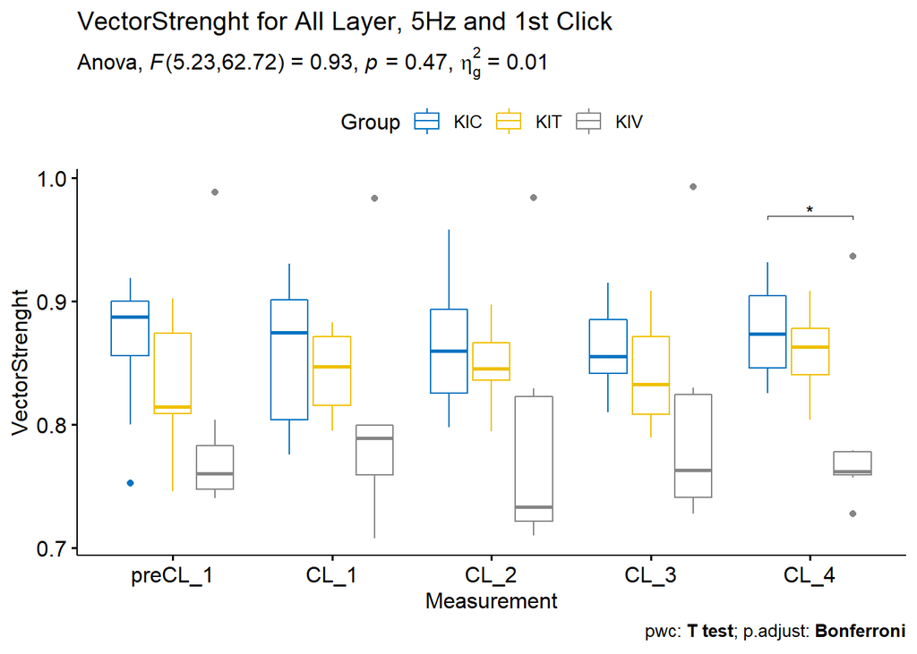

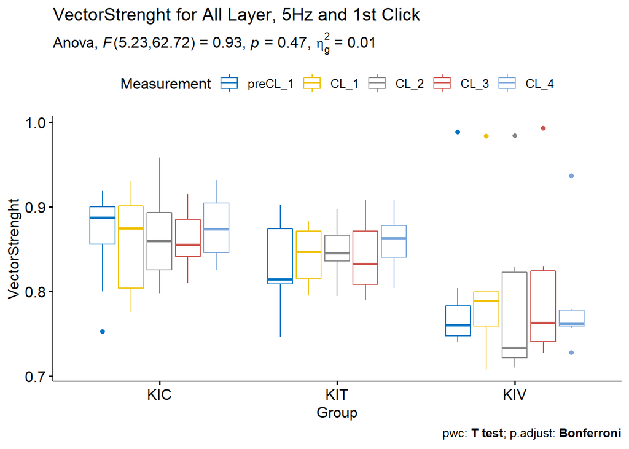

### I_II Layer

#### VectorStrenght

##### Assumptions Check

**===OUTLIERS===**

| Group | Measurement | Animal | VectorStrenght | is.outlier | is.extreme |
| --- | --- | --- | --- | --- | --- |
| KIC | CL_1 | KIC02 | 0.864206 | TRUE | FALSE |
| KIC | CL_1 | KIC15 | 0.522966 | TRUE | FALSE |
| KIT | CL_2 | KIT01 | 0.563854 | TRUE | FALSE |
| KIT | CL_2 | KIT02 | 0.840200 | TRUE | FALSE |
| KIV | CL_2 | KIV12 | 0.922077 | TRUE | FALSE |
| KIC | CL_3 | KIC02 | 0.584550 | TRUE | TRUE |
| KIC | CL_3 | KIC12 | 0.832731 | TRUE | TRUE |
| KIC | CL_3 | KIC15 | 0.502224 | TRUE | TRUE |
| KIV | CL_3 | KIV12 | 0.919868 | TRUE | FALSE |
| KIC | CL_4 | KIC15 | 0.525521 | TRUE | FALSE |
| KIV | CL_4 | KIV09 | 0.585852 | TRUE | FALSE |

**===NORMALITY ASSUMPTION===**

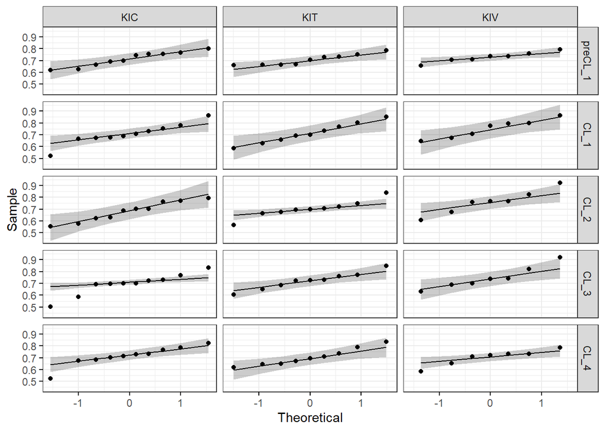

**===HOMOGENEITY OF VARIANCE ASSUMPTION===**

| Measurement | df1 | df2 | statistic | p |
| --- | --- | --- | --- | --- |
| preCL_1 | 2 | 23 | 1.397 | 0.268 |
| CL_1 | 2 | 23 | 0.020 | 0.980 |
| CL_2 | 2 | 23 | 0.393 | 0.679 |
| CL_3 | 2 | 23 | 0.146 | 0.865 |
| CL_4 | 2 | 23 | 0.122 | 0.885 |

##### Mixed ANOVA

| Effect | DFn | DFd | F | p | p..05 | ges |
| --- | --- | --- | --- | --- | --- | --- |
| Group | 2.0 | 23.00 | 0.756 | 0.481 |  | 0.041 |
| Measurement | 2.9 | 66.75 | 0.416 | 0.736 |  | 0.006 |
| Group:Measurement | 5.8 | 66.75 | 1.063 | 0.393 |  | 0.031 |

##### Post-hoc Tests

**===SIGNIFICANT TWO-WAY INTERACTION===**

**=EFFECT OF GROUP AT EACH MEASUREMENT=**

| Measurement | Effect | DFn | DFd | p | p..05 | ges | p.adj |
| --- | --- | --- | --- | --- | --- | --- | --- |
| preCL_1 | Group | 2 | 23 | 0.709 |  | 0.029 | 1.000 |
| CL_1 | Group | 2 | 23 | 0.540 |  | 0.052 | 1.000 |
| CL_2 | Group | 2 | 23 | 0.175 |  | 0.141 | 0.875 |
| CL_3 | Group | 2 | 23 | 0.429 |  | 0.071 | 1.000 |
| CL_4 | Group | 2 | 23 | 0.944 |  | 0.005 | 1.000 |

**=PAIRWISE COMPARISONS BETWEEN GROUP LEVELS=**

| Measurement | .y. | group1 | group2 | n1 | n2 | statistic | df | p | p.adj | p.adj.signif | effsize | magnitude |
| --- | --- | --- | --- | --- | --- | --- | --- | --- | --- | --- | --- | --- |
| preCL_1 | VectorStrenght | KIC | KIT | 10 | 10 | 0.206 | 16.312 | 0.839 | 1.000 | ns | 0.094 | negligible |
| preCL_1 | VectorStrenght | KIC | KIV | 10 | 7 | -0.629 | 14.976 | 0.539 | 1.000 | ns | -0.301 | small |
| preCL_1 | VectorStrenght | KIT | KIV | 10 | 7 | -0.950 | 13.157 | 0.359 | 1.000 | ns | -0.478 | small |
| CL_1 | VectorStrenght | KIC | KIT | 10 | 10 | -0.179 | 16.918 | 0.860 | 1.000 | ns | -0.082 | negligible |
| CL_1 | VectorStrenght | KIC | KIV | 10 | 7 | -1.106 | 14.085 | 0.287 | 0.861 | ns | -0.539 | moderate |
| CL_1 | VectorStrenght | KIT | KIV | 10 | 7 | -0.925 | 13.543 | 0.371 | 1.000 | ns | -0.464 | small |
| CL_2 | VectorStrenght | KIC | KIT | 10 | 10 | -0.595 | 16.998 | 0.560 | 1.000 | ns | -0.272 | small |
| CL_2 | VectorStrenght | KIC | KIV | 10 | 7 | -1.731 | 11.355 | 0.110 | 0.330 | ns | -0.867 | large |
| CL_2 | VectorStrenght | KIT | KIV | 10 | 7 | -1.296 | 10.639 | 0.222 | 0.666 | ns | -0.666 | moderate |
| CL_3 | VectorStrenght | KIC | KIT | 10 | 10 | -0.792 | 16.656 | 0.440 | 1.000 | ns | -0.361 | small |
| CL_3 | VectorStrenght | KIC | KIV | 10 | 7 | -1.202 | 12.679 | 0.251 | 0.753 | ns | -0.595 | moderate |
| CL_3 | VectorStrenght | KIT | KIV | 10 | 7 | -0.605 | 10.729 | 0.558 | 1.000 | ns | -0.311 | small |
| CL_4 | VectorStrenght | KIC | KIT | 10 | 10 | 0.248 | 16.997 | 0.807 | 1.000 | ns | 0.113 | negligible |
| CL_4 | VectorStrenght | KIC | KIV | 10 | 7 | 0.322 | 14.649 | 0.752 | 1.000 | ns | 0.155 | negligible |
| CL_4 | VectorStrenght | KIT | KIV | 10 | 7 | 0.079 | 13.617 | 0.938 | 1.000 | ns | 0.040 | negligible |

**=EFFECT OF MEASUREMENT AT EACH LEVEL OF GROUP=**

| Group | Effect | DFn | DFd | F | p | p..05 | ges | p.adj |
| --- | --- | --- | --- | --- | --- | --- | --- | --- |
| KIC | Measurement | 4 | 36 | 0.503 | 0.734 |  | 0.027 | 1.000 |
| KIT | Measurement | 4 | 32 | 0.534 | 0.712 |  | 0.012 | 1.000 |
| KIV | Measurement | 4 | 24 | 1.607 | 0.205 |  | 0.073 | 0.615 |

**=PAIRWISE COMPARISONS BETWEEN MEASUREMENTS AT EACH GROUP LEVELS=**

| Group | .y. | group1 | group2 | n1 | n2 | statistic | df | p | p.adj | p.adj.signif | effsize | magnitude |
| --- | --- | --- | --- | --- | --- | --- | --- | --- | --- | --- | --- | --- |
| KIC | VectorStrenght | preCL_1 | CL_1 | 10 | 10 | 0.137 | 9 | 0.894 | 1.000 | ns | 0.043 | negligible |
| KIC | VectorStrenght | preCL_1 | CL_2 | 10 | 10 | 1.122 | 9 | 0.291 | 1.000 | ns | 0.355 | small |
| KIC | VectorStrenght | preCL_1 | CL_3 | 10 | 10 | 0.667 | 9 | 0.522 | 1.000 | ns | 0.211 | small |
| KIC | VectorStrenght | preCL_1 | CL_4 | 10 | 10 | -0.063 | 9 | 0.951 | 1.000 | ns | -0.020 | negligible |
| KIC | VectorStrenght | CL_1 | CL_2 | 10 | 10 | 0.768 | 9 | 0.462 | 1.000 | ns | 0.243 | small |
| KIC | VectorStrenght | CL_1 | CL_3 | 10 | 10 | 0.435 | 9 | 0.674 | 1.000 | ns | 0.138 | negligible |
| KIC | VectorStrenght | CL_1 | CL_4 | 10 | 10 | -0.447 | 9 | 0.665 | 1.000 | ns | -0.141 | negligible |
| KIC | VectorStrenght | CL_2 | CL_3 | 10 | 10 | -0.766 | 9 | 0.463 | 1.000 | ns | -0.242 | small |
| KIC | VectorStrenght | CL_2 | CL_4 | 10 | 10 | -1.291 | 9 | 0.229 | 1.000 | ns | -0.408 | small |
| KIC | VectorStrenght | CL_3 | CL_4 | 10 | 10 | -0.958 | 9 | 0.363 | 1.000 | ns | -0.303 | small |
| KIT | VectorStrenght | preCL_1 | CL_1 | 10 | 10 | -0.294 | 8 | 0.777 | 1.000 | ns | -0.098 | negligible |
| KIT | VectorStrenght | preCL_1 | CL_2 | 10 | 10 | 0.335 | 8 | 0.746 | 1.000 | ns | 0.112 | negligible |
| KIT | VectorStrenght | preCL_1 | CL_3 | 10 | 10 | -0.906 | 8 | 0.391 | 1.000 | ns | -0.302 | small |
| KIT | VectorStrenght | preCL_1 | CL_4 | 10 | 10 | 0.114 | 8 | 0.912 | 1.000 | ns | 0.038 | negligible |
| KIT | VectorStrenght | CL_1 | CL_2 | 10 | 10 | 0.756 | 8 | 0.471 | 1.000 | ns | 0.252 | small |
| KIT | VectorStrenght | CL_1 | CL_3 | 10 | 10 | -0.666 | 8 | 0.524 | 1.000 | ns | -0.222 | small |
| KIT | VectorStrenght | CL_1 | CL_4 | 10 | 10 | 0.409 | 8 | 0.693 | 1.000 | ns | 0.136 | negligible |
| KIT | VectorStrenght | CL_2 | CL_3 | 10 | 10 | -2.155 | 8 | 0.063 | 0.633 | ns | -0.718 | moderate |
| KIT | VectorStrenght | CL_2 | CL_4 | 10 | 10 | -0.388 | 8 | 0.708 | 1.000 | ns | -0.129 | negligible |
| KIT | VectorStrenght | CL_3 | CL_4 | 10 | 10 | 1.083 | 8 | 0.311 | 1.000 | ns | 0.361 | small |
| KIV | VectorStrenght | preCL_1 | CL_1 | 7 | 7 | -0.835 | 6 | 0.436 | 1.000 | ns | -0.316 | small |
| KIV | VectorStrenght | preCL_1 | CL_2 | 7 | 7 | -0.891 | 6 | 0.407 | 1.000 | ns | -0.337 | small |
| KIV | VectorStrenght | preCL_1 | CL_3 | 7 | 7 | -0.567 | 6 | 0.592 | 1.000 | ns | -0.214 | small |
| KIV | VectorStrenght | preCL_1 | CL_4 | 7 | 7 | 1.525 | 6 | 0.178 | 1.000 | ns | 0.577 | moderate |
| KIV | VectorStrenght | CL_1 | CL_2 | 7 | 7 | -0.449 | 6 | 0.669 | 1.000 | ns | -0.170 | negligible |
| KIV | VectorStrenght | CL_1 | CL_3 | 7 | 7 | 0.148 | 6 | 0.887 | 1.000 | ns | 0.056 | negligible |
| KIV | VectorStrenght | CL_1 | CL_4 | 7 | 7 | 1.980 | 6 | 0.095 | 0.950 | ns | 0.748 | moderate |
| KIV | VectorStrenght | CL_2 | CL_3 | 7 | 7 | 1.083 | 6 | 0.320 | 1.000 | ns | 0.409 | small |
| KIV | VectorStrenght | CL_2 | CL_4 | 7 | 7 | 2.182 | 6 | 0.072 | 0.719 | ns | 0.825 | large |
| KIV | VectorStrenght | CL_3 | CL_4 | 7 | 7 | 1.577 | 6 | 0.166 | 1.000 | ns | 0.596 | moderate |

**===NON-SIGNIFICANT TWO-WAY INTERACTION===**

**=MAIN EFFECT OF MEASUREMENT=**

| .y. | group1 | group2 | n1 | n2 | statistic | df | p | p.adj | p.adj.signif |
| --- | --- | --- | --- | --- | --- | --- | --- | --- | --- |
| VectorStrenght | preCL_1 | CL_1 | 27 | 27 | -0.3670577 | 25 | 0.717 | 1 | ns |
| VectorStrenght | preCL_1 | CL_2 | 27 | 27 | 0.3538816 | 25 | 0.726 | 1 | ns |
| VectorStrenght | preCL_1 | CL_3 | 27 | 27 | -0.2319225 | 25 | 0.818 | 1 | ns |
| VectorStrenght | preCL_1 | CL_4 | 27 | 27 | 0.4658651 | 25 | 0.645 | 1 | ns |
| VectorStrenght | CL_1 | CL_2 | 27 | 27 | 0.8148009 | 25 | 0.423 | 1 | ns |
| VectorStrenght | CL_1 | CL_3 | 27 | 27 | 0.2217938 | 25 | 0.826 | 1 | ns |
| VectorStrenght | CL_1 | CL_4 | 27 | 27 | 1.0965895 | 25 | 0.283 | 1 | ns |
| VectorStrenght | CL_2 | CL_3 | 27 | 27 | -1.1626523 | 25 | 0.256 | 1 | ns |
| VectorStrenght | CL_2 | CL_4 | 27 | 27 | 0.0694892 | 25 | 0.945 | 1 | ns |
| VectorStrenght | CL_3 | CL_4 | 27 | 27 | 0.7580826 | 25 | 0.455 | 1 | ns |

**=MAIN EFFECT OF GROUP=**

.y.

group1

group2

n1

n2

p

p.signif

p.adj

p.adj.signif

VectorStrenght

KIC

KIT

50

50

0.5670

ns

1.0000

ns

VectorStrenght

KIC

KIV

50

35

0.0266

0.0799

ns

VectorStrenght

KIT

KIV

50

35

0.0974

ns

0.2920

ns

##### Plots

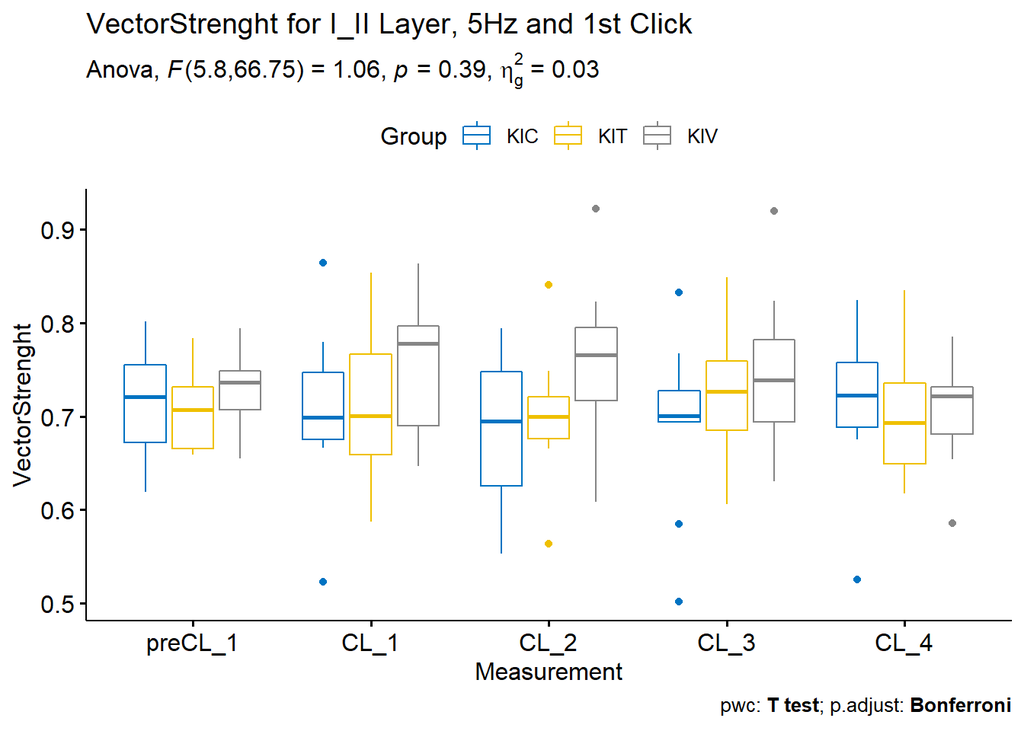

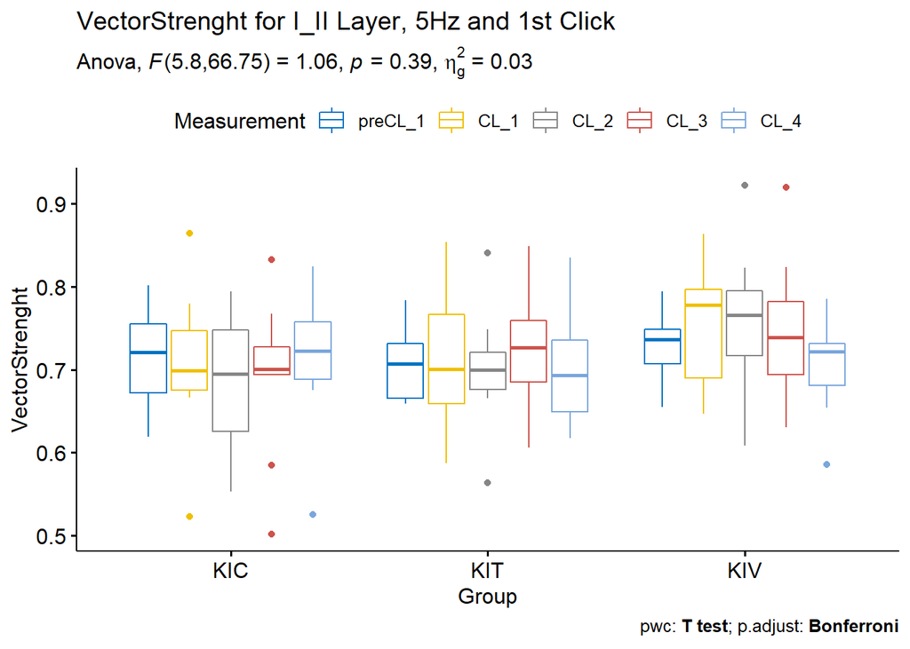

### IV Layer

#### VectorStrenght

##### Assumptions Check

**===OUTLIERS===**

| Group | Measurement | Animal | VectorStrenght | is.outlier | is.extreme |
| --- | --- | --- | --- | --- | --- |
| KIV | preCL_1 | KIV12 | 0.980571 | TRUE | TRUE |
| KIV | CL_1 | KIV03 | 0.618529 | TRUE | TRUE |
| KIV | CL_1 | KIV12 | 0.956864 | TRUE | TRUE |
| KIT | CL_2 | KIT07 | 0.728086 | TRUE | FALSE |
| KIT | CL_2 | KIT08 | 0.693779 | TRUE | FALSE |
| KIV | CL_2 | KIV03 | 0.621115 | TRUE | FALSE |
| KIV | CL_2 | KIV12 | 0.988041 | TRUE | TRUE |
| KIV | CL_3 | KIV12 | 0.992097 | TRUE | TRUE |
| KIV | CL_4 | KIV03 | 0.672781 | TRUE | FALSE |
| KIV | CL_4 | KIV12 | 0.950005 | TRUE | TRUE |

**===NORMALITY ASSUMPTION===**

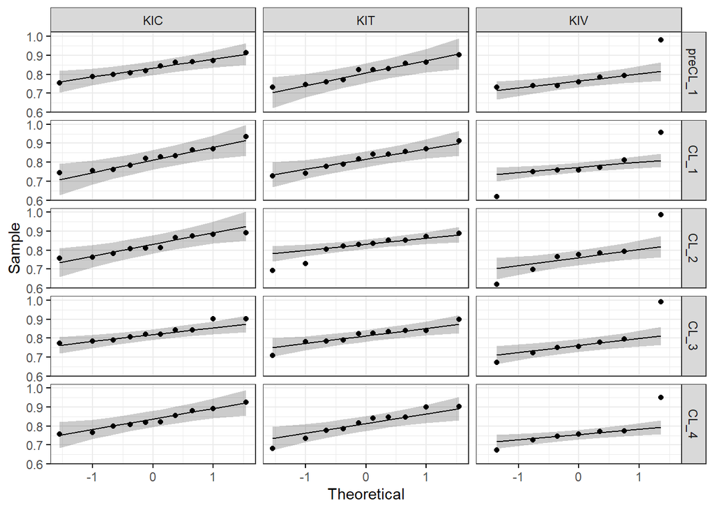

**===HOMOGENEITY OF VARIANCE ASSUMPTION===**

| Measurement | df1 | df2 | statistic | p |
| --- | --- | --- | --- | --- |
| preCL_1 | 2 | 24 | 0.105 | 0.901 |
| CL_1 | 2 | 24 | 0.156 | 0.857 |
| CL_2 | 2 | 24 | 0.676 | 0.518 |
| CL_3 | 2 | 24 | 0.680 | 0.516 |
| CL_4 | 2 | 24 | 0.141 | 0.869 |

##### Mixed ANOVA

| Effect | DFn | DFd | F | p | p..05 | ges |
| --- | --- | --- | --- | --- | --- | --- |
| Group | 2.00 | 24.00 | 1.290 | 0.294 |  | 0.082 |
| Measurement | 2.99 | 71.87 | 0.195 | 0.899 |  | 0.001 |
| Group:Measurement | 5.99 | 71.87 | 0.333 | 0.917 |  | 0.005 |

##### Post-hoc Tests

**===SIGNIFICANT TWO-WAY INTERACTION===**

**=EFFECT OF GROUP AT EACH MEASUREMENT=**

| Measurement | Effect | DFn | DFd | p | p..05 | ges | p.adj |
| --- | --- | --- | --- | --- | --- | --- | --- |
| preCL_1 | Group | 2 | 24 | 0.404 |  | 0.073 | 1 |
| CL_1 | Group | 2 | 24 | 0.395 |  | 0.075 | 1 |
| CL_2 | Group | 2 | 24 | 0.377 |  | 0.078 | 1 |
| CL_3 | Group | 2 | 24 | 0.350 |  | 0.084 | 1 |
| CL_4 | Group | 2 | 24 | 0.218 |  | 0.119 | 1 |

**=PAIRWISE COMPARISONS BETWEEN GROUP LEVELS=**

| Measurement | .y. | group1 | group2 | n1 | n2 | statistic | df | p | p.adj | p.adj.signif | effsize | magnitude |
| --- | --- | --- | --- | --- | --- | --- | --- | --- | --- | --- | --- | --- |
| preCL_1 | VectorStrenght | KIC | KIT | 10 | 10 | 0.922 | 17.543 | 0.369 | 1.000 | ns | 0.412 | small |
| preCL_1 | VectorStrenght | KIC | KIV | 10 | 7 | 1.166 | 8.573 | 0.275 | 0.825 | ns | 0.601 | moderate |
| preCL_1 | VectorStrenght | KIT | KIV | 10 | 7 | 0.551 | 9.515 | 0.595 | 1.000 | ns | 0.281 | small |
| CL_1 | VectorStrenght | KIC | KIT | 10 | 10 | 0.066 | 17.977 | 0.948 | 1.000 | ns | 0.029 | negligible |
| CL_1 | VectorStrenght | KIC | KIV | 10 | 7 | 1.052 | 9.035 | 0.320 | 0.960 | ns | 0.540 | moderate |
| CL_1 | VectorStrenght | KIT | KIV | 10 | 7 | 1.018 | 8.833 | 0.336 | 1.000 | ns | 0.523 | moderate |
| CL_2 | VectorStrenght | KIC | KIT | 10 | 10 | 0.285 | 17.265 | 0.779 | 1.000 | ns | 0.127 | negligible |
| CL_2 | VectorStrenght | KIC | KIV | 10 | 7 | 1.096 | 7.697 | 0.306 | 0.918 | ns | 0.571 | moderate |
| CL_2 | VectorStrenght | KIT | KIV | 10 | 7 | 0.909 | 8.567 | 0.388 | 1.000 | ns | 0.468 | small |
| CL_3 | VectorStrenght | KIC | KIT | 10 | 10 | 0.747 | 17.779 | 0.465 | 1.000 | ns | 0.334 | small |
| CL_3 | VectorStrenght | KIC | KIV | 10 | 7 | 1.163 | 7.665 | 0.280 | 0.840 | ns | 0.606 | moderate |
| CL_3 | VectorStrenght | KIT | KIV | 10 | 7 | 0.762 | 8.080 | 0.468 | 1.000 | ns | 0.395 | small |
| CL_4 | VectorStrenght | KIC | KIT | 10 | 10 | 0.674 | 17.050 | 0.509 | 1.000 | ns | 0.301 | small |
| CL_4 | VectorStrenght | KIC | KIV | 10 | 7 | 1.661 | 9.424 | 0.130 | 0.390 | ns | 0.848 | large |
| CL_4 | VectorStrenght | KIT | KIV | 10 | 7 | 1.074 | 11.253 | 0.305 | 0.915 | ns | 0.539 | moderate |

**=EFFECT OF MEASUREMENT AT EACH LEVEL OF GROUP=**

| Group | Effect | DFn | DFd | F | p | p..05 | ges | p.adj |
| --- | --- | --- | --- | --- | --- | --- | --- | --- |
| KIC | Measurement | 4 | 36.00 | 0.283 | 0.887 |  | 0.010 | 1 |
| KIT | Measurement | 4 | 36.00 | 0.116 | 0.976 |  | 0.003 | 1 |
| KIV | Measurement | 2 | 11.99 | 0.393 | 0.683 |  | 0.005 | 1 |

**=PAIRWISE COMPARISONS BETWEEN MEASUREMENTS AT EACH GROUP LEVELS=**

| Group | .y. | group1 | group2 | n1 | n2 | statistic | df | p | p.adj | p.adj.signif | effsize | magnitude |
| --- | --- | --- | --- | --- | --- | --- | --- | --- | --- | --- | --- | --- |
| KIC | VectorStrenght | preCL_1 | CL_1 | 10 | 10 | 0.659 | 9 | 0.526 | 1 | ns | 0.208 | small |
| KIC | VectorStrenght | preCL_1 | CL_2 | 10 | 10 | 0.409 | 9 | 0.692 | 1 | ns | 0.129 | negligible |
| KIC | VectorStrenght | preCL_1 | CL_3 | 10 | 10 | 0.240 | 9 | 0.816 | 1 | ns | 0.076 | negligible |
| KIC | VectorStrenght | preCL_1 | CL_4 | 10 | 10 | 0.009 | 9 | 0.993 | 1 | ns | 0.003 | negligible |
| KIC | VectorStrenght | CL_1 | CL_2 | 10 | 10 | -0.476 | 9 | 0.646 | 1 | ns | -0.150 | negligible |
| KIC | VectorStrenght | CL_1 | CL_3 | 10 | 10 | -0.605 | 9 | 0.560 | 1 | ns | -0.191 | negligible |
| KIC | VectorStrenght | CL_1 | CL_4 | 10 | 10 | -1.173 | 9 | 0.271 | 1 | ns | -0.371 | small |
| KIC | VectorStrenght | CL_2 | CL_3 | 10 | 10 | -0.503 | 9 | 0.627 | 1 | ns | -0.159 | negligible |
| KIC | VectorStrenght | CL_2 | CL_4 | 10 | 10 | -0.752 | 9 | 0.471 | 1 | ns | -0.238 | small |
| KIC | VectorStrenght | CL_3 | CL_4 | 10 | 10 | -0.435 | 9 | 0.674 | 1 | ns | -0.138 | negligible |
| KIT | VectorStrenght | preCL_1 | CL_1 | 10 | 10 | -0.561 | 9 | 0.589 | 1 | ns | -0.177 | negligible |
| KIT | VectorStrenght | preCL_1 | CL_2 | 10 | 10 | -0.558 | 9 | 0.590 | 1 | ns | -0.177 | negligible |
| KIT | VectorStrenght | preCL_1 | CL_3 | 10 | 10 | -0.086 | 9 | 0.934 | 1 | ns | -0.027 | negligible |
| KIT | VectorStrenght | preCL_1 | CL_4 | 10 | 10 | -0.168 | 9 | 0.870 | 1 | ns | -0.053 | negligible |
| KIT | VectorStrenght | CL_1 | CL_2 | 10 | 10 | -0.013 | 9 | 0.990 | 1 | ns | -0.004 | negligible |
| KIT | VectorStrenght | CL_1 | CL_3 | 10 | 10 | 0.404 | 9 | 0.696 | 1 | ns | 0.128 | negligible |
| KIT | VectorStrenght | CL_1 | CL_4 | 10 | 10 | 0.289 | 9 | 0.779 | 1 | ns | 0.091 | negligible |
| KIT | VectorStrenght | CL_2 | CL_3 | 10 | 10 | 0.510 | 9 | 0.622 | 1 | ns | 0.161 | negligible |
| KIT | VectorStrenght | CL_2 | CL_4 | 10 | 10 | 0.352 | 9 | 0.733 | 1 | ns | 0.111 | negligible |
| KIT | VectorStrenght | CL_3 | CL_4 | 10 | 10 | -0.071 | 9 | 0.945 | 1 | ns | -0.022 | negligible |
| KIV | VectorStrenght | preCL_1 | CL_1 | 7 | 7 | 0.731 | 6 | 0.492 | 1 | ns | 0.276 | small |
| KIV | VectorStrenght | preCL_1 | CL_2 | 7 | 7 | 0.597 | 6 | 0.573 | 1 | ns | 0.225 | small |
| KIV | VectorStrenght | preCL_1 | CL_3 | 7 | 7 | 0.540 | 6 | 0.609 | 1 | ns | 0.204 | small |
| KIV | VectorStrenght | preCL_1 | CL_4 | 7 | 7 | 1.708 | 6 | 0.139 | 1 | ns | 0.646 | moderate |
| KIV | VectorStrenght | CL_1 | CL_2 | 7 | 7 | -0.034 | 6 | 0.974 | 1 | ns | -0.013 | negligible |
| KIV | VectorStrenght | CL_1 | CL_3 | 7 | 7 | -0.342 | 6 | 0.744 | 1 | ns | -0.129 | negligible |
| KIV | VectorStrenght | CL_1 | CL_4 | 7 | 7 | 0.278 | 6 | 0.790 | 1 | ns | 0.105 | negligible |
| KIV | VectorStrenght | CL_2 | CL_3 | 7 | 7 | -0.443 | 6 | 0.673 | 1 | ns | -0.168 | negligible |
| KIV | VectorStrenght | CL_2 | CL_4 | 7 | 7 | 0.233 | 6 | 0.824 | 1 | ns | 0.088 | negligible |
| KIV | VectorStrenght | CL_3 | CL_4 | 7 | 7 | 0.848 | 6 | 0.429 | 1 | ns | 0.320 | small |

**===NON-SIGNIFICANT TWO-WAY INTERACTION===**

**=MAIN EFFECT OF MEASUREMENT=**

| .y. | group1 | group2 | n1 | n2 | statistic | df | p | p.adj | p.adj.signif |
| --- | --- | --- | --- | --- | --- | --- | --- | --- | --- |
| VectorStrenght | preCL_1 | CL_1 | 27 | 27 | 0.6244038 | 26 | 0.538 | 1 | ns |
| VectorStrenght | preCL_1 | CL_2 | 27 | 27 | 0.3949468 | 26 | 0.696 | 1 | ns |
| VectorStrenght | preCL_1 | CL_3 | 27 | 27 | 0.3531680 | 26 | 0.727 | 1 | ns |
| VectorStrenght | preCL_1 | CL_4 | 27 | 27 | 0.4473520 | 26 | 0.658 | 1 | ns |
| VectorStrenght | CL_1 | CL_2 | 27 | 27 | -0.3565370 | 26 | 0.724 | 1 | ns |
| VectorStrenght | CL_1 | CL_3 | 27 | 27 | -0.3298694 | 26 | 0.744 | 1 | ns |
| VectorStrenght | CL_1 | CL_4 | 27 | 27 | -0.2664841 | 26 | 0.792 | 1 | ns |
| VectorStrenght | CL_2 | CL_3 | 27 | 27 | -0.0934024 | 26 | 0.926 | 1 | ns |
| VectorStrenght | CL_2 | CL_4 | 27 | 27 | 0.0191842 | 26 | 0.985 | 1 | ns |
| VectorStrenght | CL_3 | CL_4 | 27 | 27 | 0.0976267 | 26 | 0.923 | 1 | ns |

**=MAIN EFFECT OF GROUP=**

.y.

group1

group2

n1

n2

p

p.signif

p.adj

p.adj.signif

VectorStrenght

KIC

KIT

50

50

0.322000

ns

0.96500

ns

VectorStrenght

KIC

KIV

50

35

0.000954

***

0.00286

VectorStrenght

KIT

KIV

50

35

0.014500

0.04350

##### Plots

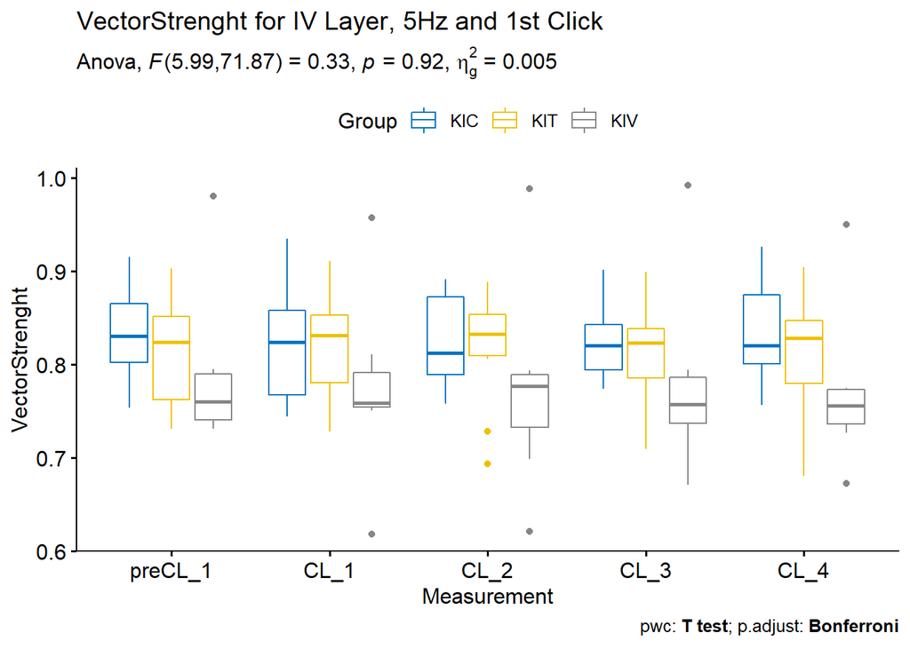

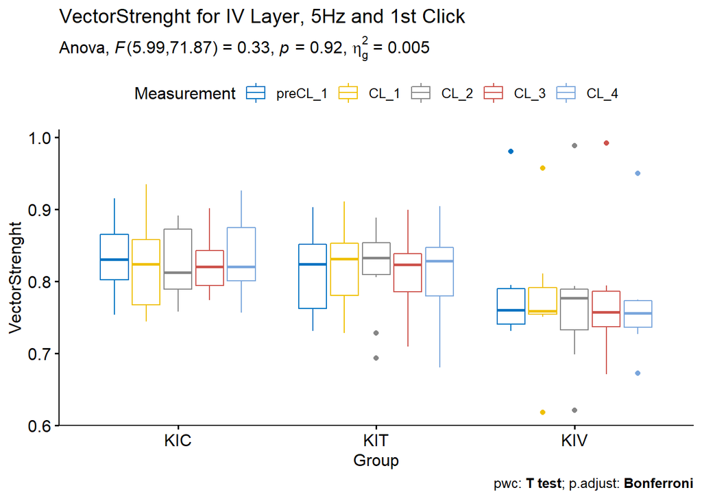

### V Layer

#### VectorStrenght

##### Assumptions Check

**===OUTLIERS===**

| Group | Measurement | Animal | VectorStrenght | is.outlier | is.extreme |
| --- | --- | --- | --- | --- | --- |
| KIT | preCL_1 | KIT11 | 0.679752 | TRUE | FALSE |
| KIT | preCL_1 | KIT12 | 0.669541 | TRUE | FALSE |
| KIV | preCL_1 | KIV12 | 0.896058 | TRUE | TRUE |
| KIV | CL_1 | KIV12 | 0.903475 | TRUE | TRUE |
| KIV | CL_2 | KIV12 | 0.943130 | TRUE | TRUE |
| KIV | CL_3 | KIV12 | 0.923227 | TRUE | TRUE |
| KIV | CL_3 | KIV17 | 0.688007 | TRUE | TRUE |
| KIT | CL_4 | KIT09 | 0.714736 | TRUE | FALSE |
| KIV | CL_4 | KIV12 | 0.794029 | TRUE | FALSE |
| KIV | CL_4 | KIV17 | 0.686393 | TRUE | TRUE |

**===NORMALITY ASSUMPTION===**

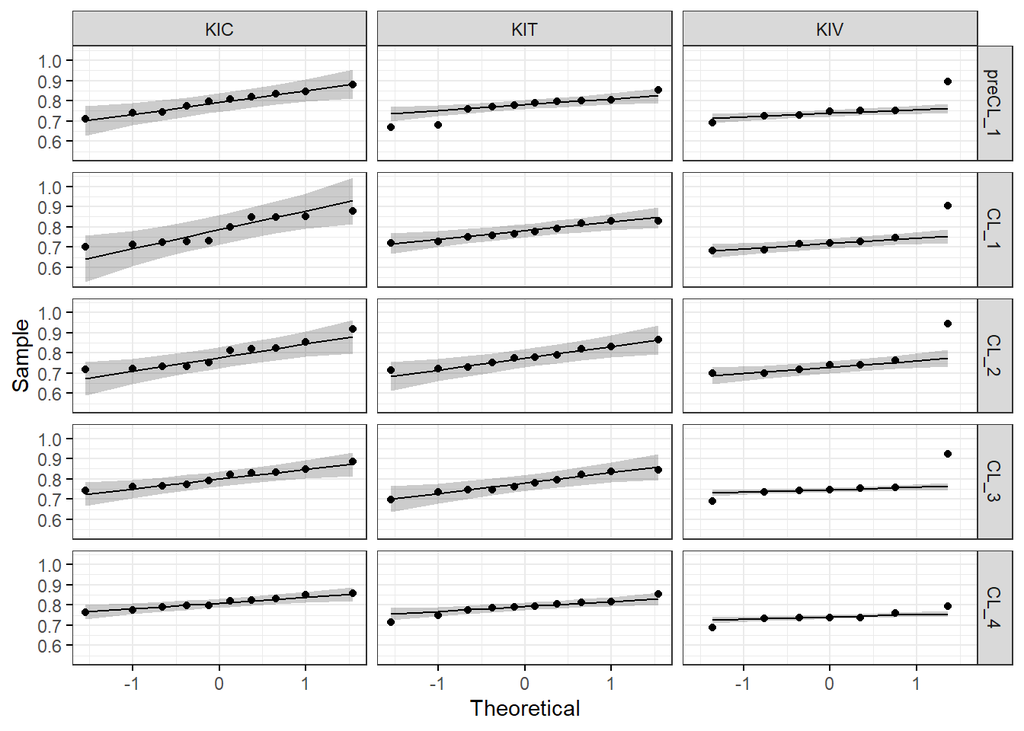

**===HOMOGENEITY OF VARIANCE ASSUMPTION===**

| Measurement | df1 | df2 | statistic | p |
| --- | --- | --- | --- | --- |
| preCL_1 | 2 | 24 | 0.049 | 0.952 |
| CL_1 | 2 | 24 | 1.684 | 0.207 |
| CL_2 | 2 | 24 | 0.426 | 0.658 |
| CL_3 | 2 | 24 | 0.002 | 0.998 |
| CL_4 | 2 | 24 | 0.234 | 0.794 |

##### Mixed ANOVA

| Effect | DFn | DFd | F | p | p..05 | ges |
| --- | --- | --- | --- | --- | --- | --- |
| Group | 2.00 | 24.00 | 1.562 | 0.230 |  | 0.097 |
| Measurement | 3.04 | 72.97 | 1.478 | 0.227 |  | 0.010 |
| Group:Measurement | 6.08 | 72.97 | 1.125 | 0.356 |  | 0.016 |

##### Post-hoc Tests

**===SIGNIFICANT TWO-WAY INTERACTION===**

**=EFFECT OF GROUP AT EACH MEASUREMENT=**

Measurement

Effect

DFn

DFd

p

p..05

ges

p.adj

preCL_1

Group

2

24

0.374

0.079

1.00

CL_1

Group

2

24

0.356

0.083

1.00

CL_2

Group

2

24

0.654

0.035

1.00

CL_3

Group

2

24

0.288

0.099

1.00

CL_4

Group

2

24

0.002

0.418

0.01

**=PAIRWISE COMPARISONS BETWEEN GROUP LEVELS=**

Measurement

.y.

group1

group2

n1

n2

statistic

df

p

p.adj

p.adj.signif

effsize

magnitude

preCL_1

VectorStrenght

KIC

KIT

10

10

1.006

17.925

0.328

0.984

ns

0.450

small

preCL_1

VectorStrenght

KIC

KIV

10

7

1.320

11.292

0.213

0.639

ns

0.662

moderate

preCL_1

VectorStrenght

KIT

KIV

10

7

0.478

11.863

0.641

1.000

ns

0.239

small

CL_1

VectorStrenght

KIC

KIT

10

10

0.223

14.191

0.827

1.000

ns

0.100

negligible

CL_1

VectorStrenght

KIC

KIV

10

7

1.173

12.336

0.263

0.789

ns

0.582

moderate

CL_1

VectorStrenght

KIT

KIV

10

7

1.178

8.277

0.272

0.816

ns

0.609

moderate

CL_2

VectorStrenght

KIC

KIT

10

10

0.368

16.570

0.718

1.000

ns

0.164

negligible

CL_2

VectorStrenght

KIC

KIV

10

7

0.788

11.056

0.447

1.000

ns

0.396

small

CL_2

VectorStrenght

KIT

KIV

10

7

0.576

8.911

0.579

1.000

ns

0.296

small

CL_3

VectorStrenght

KIC

KIT

10

10

1.369

17.940

0.188

0.564

ns

0.612

moderate

CL_3

VectorStrenght

KIC

KIV

10

7

1.314

9.107

0.221

0.663

ns

0.673

moderate

CL_3

VectorStrenght

KIT

KIV

10

7

0.404

9.467

0.695

1.000

ns

0.206

small

CL_4

VectorStrenght

KIC

KIT

10

10

1.361

17.301

0.191

0.573

ns

0.609

moderate

CL_4

VectorStrenght

KIC

KIV

10

7

4.419

12.727

0.001

0.002

2.185

large

CL_4

VectorStrenght

KIT

KIV

10

7

2.804

14.320

0.014

0.041

1.362

large

**=EFFECT OF MEASUREMENT AT EACH LEVEL OF GROUP=**

| Group | Effect | DFn | DFd | F | p | p..05 | ges | p.adj |
| --- | --- | --- | --- | --- | --- | --- | --- | --- |
| KIC | Measurement | 4 | 36 | 2.117 | 0.099 |  | 0.038 | 0.297 |
| KIT | Measurement | 4 | 36 | 0.746 | 0.567 |  | 0.018 | 1.000 |
| KIV | Measurement | 4 | 24 | 0.967 | 0.444 |  | 0.022 | 1.000 |

**=PAIRWISE COMPARISONS BETWEEN MEASUREMENTS AT EACH GROUP LEVELS=**

| Group | .y. | group1 | group2 | n1 | n2 | statistic | df | p | p.adj | p.adj.signif | effsize | magnitude |
| --- | --- | --- | --- | --- | --- | --- | --- | --- | --- | --- | --- | --- |
| KIC | VectorStrenght | preCL_1 | CL_1 | 10 | 10 | 1.093 | 9 | 0.303 | 1.000 | ns | 0.346 | small |
| KIC | VectorStrenght | preCL_1 | CL_2 | 10 | 10 | 0.559 | 9 | 0.590 | 1.000 | ns | 0.177 | negligible |
| KIC | VectorStrenght | preCL_1 | CL_3 | 10 | 10 | -0.883 | 9 | 0.400 | 1.000 | ns | -0.279 | small |
| KIC | VectorStrenght | preCL_1 | CL_4 | 10 | 10 | -1.499 | 9 | 0.168 | 1.000 | ns | -0.474 | small |
| KIC | VectorStrenght | CL_1 | CL_2 | 10 | 10 | -0.577 | 9 | 0.578 | 1.000 | ns | -0.182 | negligible |
| KIC | VectorStrenght | CL_1 | CL_3 | 10 | 10 | -2.160 | 9 | 0.059 | 0.591 | ns | -0.683 | moderate |
| KIC | VectorStrenght | CL_1 | CL_4 | 10 | 10 | -2.004 | 9 | 0.076 | 0.760 | ns | -0.634 | moderate |
| KIC | VectorStrenght | CL_2 | CL_3 | 10 | 10 | -1.843 | 9 | 0.098 | 0.984 | ns | -0.583 | moderate |
| KIC | VectorStrenght | CL_2 | CL_4 | 10 | 10 | -1.601 | 9 | 0.144 | 1.000 | ns | -0.506 | moderate |
| KIC | VectorStrenght | CL_3 | CL_4 | 10 | 10 | -0.813 | 9 | 0.437 | 1.000 | ns | -0.257 | small |
| KIT | VectorStrenght | preCL_1 | CL_1 | 10 | 10 | -0.392 | 9 | 0.704 | 1.000 | ns | -0.124 | negligible |
| KIT | VectorStrenght | preCL_1 | CL_2 | 10 | 10 | -0.622 | 9 | 0.549 | 1.000 | ns | -0.197 | negligible |
| KIT | VectorStrenght | preCL_1 | CL_3 | 10 | 10 | -0.555 | 9 | 0.593 | 1.000 | ns | -0.175 | negligible |
| KIT | VectorStrenght | preCL_1 | CL_4 | 10 | 10 | -1.108 | 9 | 0.297 | 1.000 | ns | -0.350 | small |
| KIT | VectorStrenght | CL_1 | CL_2 | 10 | 10 | -0.155 | 9 | 0.880 | 1.000 | ns | -0.049 | negligible |
| KIT | VectorStrenght | CL_1 | CL_3 | 10 | 10 | -0.023 | 9 | 0.982 | 1.000 | ns | -0.007 | negligible |
| KIT | VectorStrenght | CL_1 | CL_4 | 10 | 10 | -1.286 | 9 | 0.231 | 1.000 | ns | -0.407 | small |
| KIT | VectorStrenght | CL_2 | CL_3 | 10 | 10 | 0.286 | 9 | 0.782 | 1.000 | ns | 0.090 | negligible |
| KIT | VectorStrenght | CL_2 | CL_4 | 10 | 10 | -1.169 | 9 | 0.272 | 1.000 | ns | -0.370 | small |
| KIT | VectorStrenght | CL_3 | CL_4 | 10 | 10 | -1.336 | 9 | 0.214 | 1.000 | ns | -0.422 | small |
| KIV | VectorStrenght | preCL_1 | CL_1 | 7 | 7 | 1.485 | 6 | 0.188 | 1.000 | ns | 0.561 | moderate |
| KIV | VectorStrenght | preCL_1 | CL_2 | 7 | 7 | -0.084 | 6 | 0.936 | 1.000 | ns | -0.032 | negligible |
| KIV | VectorStrenght | preCL_1 | CL_3 | 7 | 7 | -0.716 | 6 | 0.501 | 1.000 | ns | -0.271 | small |
| KIV | VectorStrenght | preCL_1 | CL_4 | 7 | 7 | 0.853 | 6 | 0.426 | 1.000 | ns | 0.322 | small |
| KIV | VectorStrenght | CL_1 | CL_2 | 7 | 7 | -2.862 | 6 | 0.029 | 0.287 | ns | -1.082 | large |
| KIV | VectorStrenght | CL_1 | CL_3 | 7 | 7 | -2.617 | 6 | 0.040 | 0.397 | ns | -0.989 | large |
| KIV | VectorStrenght | CL_1 | CL_4 | 7 | 7 | -0.056 | 6 | 0.958 | 1.000 | ns | -0.021 | negligible |
| KIV | VectorStrenght | CL_2 | CL_3 | 7 | 7 | -0.583 | 6 | 0.581 | 1.000 | ns | -0.220 | small |
| KIV | VectorStrenght | CL_2 | CL_4 | 7 | 7 | 0.686 | 6 | 0.518 | 1.000 | ns | 0.259 | small |
| KIV | VectorStrenght | CL_3 | CL_4 | 7 | 7 | 1.241 | 6 | 0.261 | 1.000 | ns | 0.469 | small |

**===NON-SIGNIFICANT TWO-WAY INTERACTION===**

**=MAIN EFFECT OF MEASUREMENT=**

| .y. | group1 | group2 | n1 | n2 | statistic | df | p | p.adj | p.adj.signif |
| --- | --- | --- | --- | --- | --- | --- | --- | --- | --- |
| VectorStrenght | preCL_1 | CL_1 | 27 | 27 | 0.9421831 | 26 | 0.355 | 1.000 | ns |
| VectorStrenght | preCL_1 | CL_2 | 27 | 27 | -0.0293544 | 26 | 0.977 | 1.000 | ns |
| VectorStrenght | preCL_1 | CL_3 | 27 | 27 | -1.2767747 | 26 | 0.213 | 1.000 | ns |
| VectorStrenght | preCL_1 | CL_4 | 27 | 27 | -0.9660488 | 26 | 0.343 | 1.000 | ns |
| VectorStrenght | CL_1 | CL_2 | 27 | 27 | -1.3005589 | 26 | 0.205 | 1.000 | ns |
| VectorStrenght | CL_1 | CL_3 | 27 | 27 | -2.6303664 | 26 | 0.014 | 0.141 | ns |
| VectorStrenght | CL_1 | CL_4 | 27 | 27 | -1.8859750 | 26 | 0.070 | 0.705 | ns |
| VectorStrenght | CL_2 | CL_3 | 27 | 27 | -1.5095627 | 26 | 0.143 | 1.000 | ns |
| VectorStrenght | CL_2 | CL_4 | 27 | 27 | -0.9052355 | 26 | 0.374 | 1.000 | ns |
| VectorStrenght | CL_3 | CL_4 | 27 | 27 | -0.1045657 | 26 | 0.918 | 1.000 | ns |

**=MAIN EFFECT OF GROUP=**

.y.

group1

group2

n1

n2

p

p.signif

p.adj

p.adj.signif

VectorStrenght

KIC

KIT

50

50

0.100000

ns

0.301000

ns

VectorStrenght

KIC

KIV

50

35

0.000291

***

0.000872

***

VectorStrenght

KIT

KIV

50

35

0.028000

0.084100

ns

##### Plots

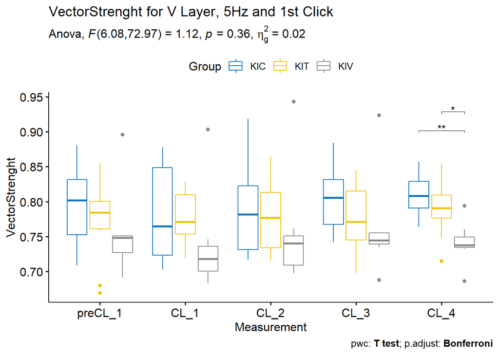

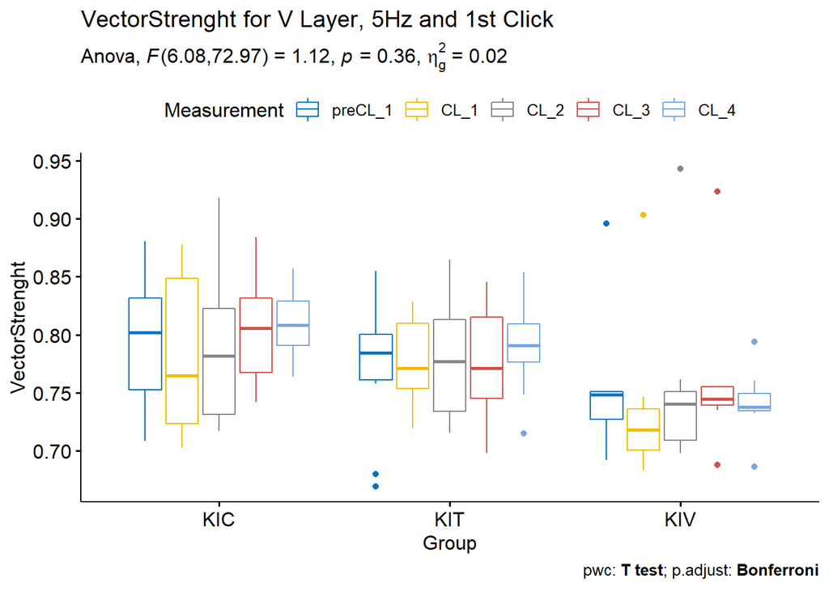

### VI Layer

#### VectorStrenght

##### Assumptions Check

**===OUTLIERS===**

| Group | Measurement | Animal | VectorStrenght | is.outlier | is.extreme |
| --- | --- | --- | --- | --- | --- |
| KIC | preCL_1 | KIC15 | 0.881512 | TRUE | FALSE |
| KIV | preCL_1 | KIV02 | 0.659122 | TRUE | FALSE |
| KIV | preCL_1 | KIV03 | 0.739975 | TRUE | FALSE |
| KIC | CL_1 | KIC15 | 0.910618 | TRUE | TRUE |
| KIC | CL_2 | KIC15 | 0.931327 | TRUE | TRUE |
| KIC | CL_2 | KIC16 | 0.803306 | TRUE | FALSE |
| KIV | CL_2 | KIV03 | 0.772627 | TRUE | FALSE |
| KIC | CL_3 | KIC15 | 0.952973 | TRUE | TRUE |
| KIC | CL_3 | KIC16 | 0.762109 | TRUE | FALSE |
| KIC | CL_4 | KIC15 | 0.937564 | TRUE | FALSE |
| KIV | CL_4 | KIV03 | 0.788763 | TRUE | FALSE |

**===NORMALITY ASSUMPTION===**

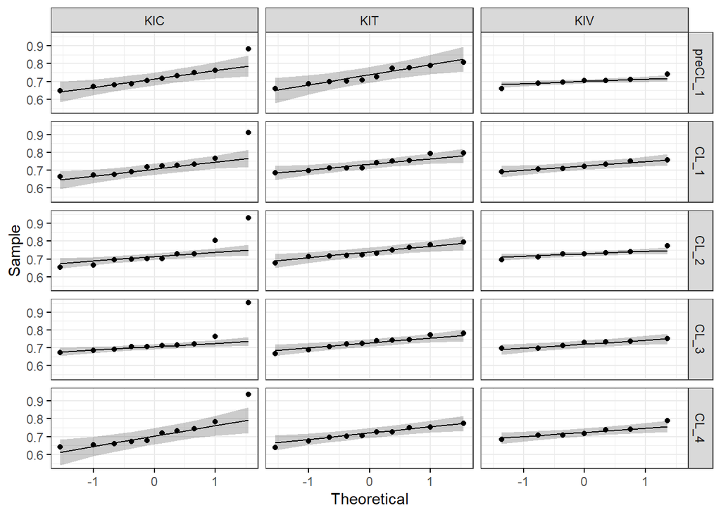

**===HOMOGENEITY OF VARIANCE ASSUMPTION===**

| Measurement | df1 | df2 | statistic | p |
| --- | --- | --- | --- | --- |
| preCL_1 | 2 | 24 | 1.495 | 0.244 |
| CL_1 | 2 | 24 | 1.019 | 0.376 |
| CL_2 | 2 | 24 | 1.040 | 0.369 |
| CL_3 | 2 | 24 | 0.558 | 0.580 |
| CL_4 | 2 | 24 | 1.818 | 0.184 |

##### Mixed ANOVA

Effect

DFn

DFd

F

p

p..05

ges

Group

2

24

0.062

0.940

0.005

Measurement

4

96

2.500

0.048

0.010

Group:Measurement

8

96

1.548

0.151

0.012

##### Post-hoc Tests

**===SIGNIFICANT TWO-WAY INTERACTION===**

**=EFFECT OF GROUP AT EACH MEASUREMENT=**

| Measurement | Effect | DFn | DFd | p | p..05 | ges | p.adj |
| --- | --- | --- | --- | --- | --- | --- | --- |
| preCL_1 | Group | 2 | 24 | 0.459 |  | 0.063 | 1 |
| CL_1 | Group | 2 | 24 | 0.895 |  | 0.009 | 1 |
| CL_2 | Group | 2 | 24 | 0.954 |  | 0.004 | 1 |
| CL_3 | Group | 2 | 24 | 0.938 |  | 0.005 | 1 |
| CL_4 | Group | 2 | 24 | 0.920 |  | 0.007 | 1 |

**=PAIRWISE COMPARISONS BETWEEN GROUP LEVELS=**

| Measurement | .y. | group1 | group2 | n1 | n2 | statistic | df | p | p.adj | p.adj.signif | effsize | magnitude |
| --- | --- | --- | --- | --- | --- | --- | --- | --- | --- | --- | --- | --- |
| preCL_1 | VectorStrenght | KIC | KIT | 10 | 10 | -0.367 | 16.834 | 0.718 | 1.000 | ns | -0.164 | negligible |
| preCL_1 | VectorStrenght | KIC | KIV | 10 | 7 | 0.996 | 12.202 | 0.339 | 1.000 | ns | 0.457 | small |
| preCL_1 | VectorStrenght | KIT | KIV | 10 | 7 | 1.755 | 13.770 | 0.102 | 0.306 | ns | 0.816 | large |
| CL_1 | VectorStrenght | KIC | KIT | 10 | 10 | -0.279 | 13.715 | 0.784 | 1.000 | ns | -0.125 | negligible |
| CL_1 | VectorStrenght | KIC | KIV | 10 | 7 | 0.177 | 11.562 | 0.862 | 1.000 | ns | 0.081 | negligible |
| CL_1 | VectorStrenght | KIT | KIV | 10 | 7 | 0.768 | 14.853 | 0.455 | 1.000 | ns | 0.363 | small |
| CL_2 | VectorStrenght | KIC | KIT | 10 | 10 | -0.237 | 12.230 | 0.816 | 1.000 | ns | -0.106 | negligible |
| CL_2 | VectorStrenght | KIC | KIV | 10 | 7 | 0.011 | 11.106 | 0.991 | 1.000 | ns | 0.005 | negligible |
| CL_2 | VectorStrenght | KIT | KIV | 10 | 7 | 0.486 | 15.000 | 0.634 | 1.000 | ns | 0.232 | small |
| CL_3 | VectorStrenght | KIC | KIT | 10 | 10 | 0.122 | 12.234 | 0.905 | 1.000 | ns | 0.055 | negligible |
| CL_3 | VectorStrenght | KIC | KIV | 10 | 7 | 0.363 | 10.577 | 0.724 | 1.000 | ns | 0.164 | negligible |
| CL_3 | VectorStrenght | KIT | KIV | 10 | 7 | 0.468 | 14.684 | 0.647 | 1.000 | ns | 0.220 | small |
| CL_4 | VectorStrenght | KIC | KIT | 10 | 10 | 0.252 | 12.519 | 0.805 | 1.000 | ns | 0.113 | negligible |
| CL_4 | VectorStrenght | KIC | KIV | 10 | 7 | -0.138 | 12.383 | 0.893 | 1.000 | ns | -0.063 | negligible |
| CL_4 | VectorStrenght | KIT | KIV | 10 | 7 | -0.665 | 14.282 | 0.517 | 1.000 | ns | -0.323 | small |

**=EFFECT OF MEASUREMENT AT EACH LEVEL OF GROUP=**

Group

Effect

DFn

DFd

F

p

p..05

ges

p.adj

KIC

Measurement

4

36

0.540

0.707

0.003

1.000

KIT

Measurement

4

36

1.907

0.130

0.046

0.390

KIV

Measurement

4

24

4.682

0.006

0.161

0.018

**=PAIRWISE COMPARISONS BETWEEN MEASUREMENTS AT EACH GROUP LEVELS=**

| Group | .y. | group1 | group2 | n1 | n2 | statistic | df | p | p.adj | p.adj.signif | effsize | magnitude |
| --- | --- | --- | --- | --- | --- | --- | --- | --- | --- | --- | --- | --- |
| KIC | VectorStrenght | preCL_1 | CL_1 | 10 | 10 | -0.588 | 9 | 0.571 | 1.000 | ns | -0.186 | negligible |
| KIC | VectorStrenght | preCL_1 | CL_2 | 10 | 10 | -0.788 | 9 | 0.451 | 1.000 | ns | -0.249 | small |
| KIC | VectorStrenght | preCL_1 | CL_3 | 10 | 10 | -0.989 | 9 | 0.348 | 1.000 | ns | -0.313 | small |
| KIC | VectorStrenght | preCL_1 | CL_4 | 10 | 10 | 0.120 | 9 | 0.907 | 1.000 | ns | 0.038 | negligible |
| KIC | VectorStrenght | CL_1 | CL_2 | 10 | 10 | -0.283 | 9 | 0.784 | 1.000 | ns | -0.089 | negligible |
| KIC | VectorStrenght | CL_1 | CL_3 | 10 | 10 | -0.532 | 9 | 0.608 | 1.000 | ns | -0.168 | negligible |
| KIC | VectorStrenght | CL_1 | CL_4 | 10 | 10 | 0.751 | 9 | 0.472 | 1.000 | ns | 0.237 | small |
| KIC | VectorStrenght | CL_2 | CL_3 | 10 | 10 | -0.256 | 9 | 0.804 | 1.000 | ns | -0.081 | negligible |
| KIC | VectorStrenght | CL_2 | CL_4 | 10 | 10 | 1.097 | 9 | 0.301 | 1.000 | ns | 0.347 | small |
| KIC | VectorStrenght | CL_3 | CL_4 | 10 | 10 | 1.147 | 9 | 0.281 | 1.000 | ns | 0.363 | small |
| KIT | VectorStrenght | preCL_1 | CL_1 | 10 | 10 | -0.261 | 9 | 0.800 | 1.000 | ns | -0.082 | negligible |
| KIT | VectorStrenght | preCL_1 | CL_2 | 10 | 10 | -0.357 | 9 | 0.729 | 1.000 | ns | -0.113 | negligible |
| KIT | VectorStrenght | preCL_1 | CL_3 | 10 | 10 | 0.353 | 9 | 0.732 | 1.000 | ns | 0.112 | negligible |
| KIT | VectorStrenght | preCL_1 | CL_4 | 10 | 10 | 2.077 | 9 | 0.068 | 0.676 | ns | 0.657 | moderate |
| KIT | VectorStrenght | CL_1 | CL_2 | 10 | 10 | -0.258 | 9 | 0.802 | 1.000 | ns | -0.082 | negligible |
| KIT | VectorStrenght | CL_1 | CL_3 | 10 | 10 | 0.744 | 9 | 0.476 | 1.000 | ns | 0.235 | small |
| KIT | VectorStrenght | CL_1 | CL_4 | 10 | 10 | 2.520 | 9 | 0.033 | 0.328 | ns | 0.797 | moderate |
| KIT | VectorStrenght | CL_2 | CL_3 | 10 | 10 | 0.876 | 9 | 0.404 | 1.000 | ns | 0.277 | small |
| KIT | VectorStrenght | CL_2 | CL_4 | 10 | 10 | 2.491 | 9 | 0.034 | 0.344 | ns | 0.788 | moderate |
| KIT | VectorStrenght | CL_3 | CL_4 | 10 | 10 | 1.858 | 9 | 0.096 | 0.961 | ns | 0.588 | moderate |
| KIV | VectorStrenght | preCL_1 | CL_1 | 7 | 7 | -2.818 | 6 | 0.030 | 0.304 | ns | -1.065 | large |
| KIV | VectorStrenght | preCL_1 | CL_2 | 7 | 7 | -6.011 | 6 | 0.001 | 0.010 | ** | -2.272 | large |
| KIV | VectorStrenght | preCL_1 | CL_3 | 7 | 7 | -3.534 | 6 | 0.012 | 0.123 | ns | -1.336 | large |
| KIV | VectorStrenght | preCL_1 | CL_4 | 7 | 7 | -2.176 | 6 | 0.072 | 0.725 | ns | -0.822 | large |
| KIV | VectorStrenght | CL_1 | CL_2 | 7 | 7 | -1.072 | 6 | 0.325 | 1.000 | ns | -0.405 | small |
| KIV | VectorStrenght | CL_1 | CL_3 | 7 | 7 | 0.228 | 6 | 0.827 | 1.000 | ns | 0.086 | negligible |
| KIV | VectorStrenght | CL_1 | CL_4 | 7 | 7 | -0.278 | 6 | 0.790 | 1.000 | ns | -0.105 | negligible |
| KIV | VectorStrenght | CL_2 | CL_3 | 7 | 7 | 1.937 | 6 | 0.101 | 1.000 | ns | 0.732 | moderate |
| KIV | VectorStrenght | CL_2 | CL_4 | 7 | 7 | 0.533 | 6 | 0.613 | 1.000 | ns | 0.201 | small |
| KIV | VectorStrenght | CL_3 | CL_4 | 7 | 7 | -0.336 | 6 | 0.748 | 1.000 | ns | -0.127 | negligible |

**===NON-SIGNIFICANT TWO-WAY INTERACTION===**

**=MAIN EFFECT OF MEASUREMENT=**

| .y. | group1 | group2 | n1 | n2 | statistic | df | p | p.adj | p.adj.signif |
| --- | --- | --- | --- | --- | --- | --- | --- | --- | --- |
| VectorStrenght | preCL_1 | CL_1 | 27 | 27 | -1.6392131 | 26 | 0.113 | 1.000 | ns |
| VectorStrenght | preCL_1 | CL_2 | 27 | 27 | -1.9846598 | 26 | 0.058 | 0.578 | ns |
| VectorStrenght | preCL_1 | CL_3 | 27 | 27 | -1.3400964 | 26 | 0.192 | 1.000 | ns |
| VectorStrenght | preCL_1 | CL_4 | 27 | 27 | 0.1244443 | 26 | 0.902 | 1.000 | ns |
| VectorStrenght | CL_1 | CL_2 | 27 | 27 | -0.7609785 | 26 | 0.454 | 1.000 | ns |
| VectorStrenght | CL_1 | CL_3 | 27 | 27 | 0.2811644 | 26 | 0.781 | 1.000 | ns |
| VectorStrenght | CL_1 | CL_4 | 27 | 27 | 1.9373795 | 26 | 0.064 | 0.636 | ns |
| VectorStrenght | CL_2 | CL_3 | 27 | 27 | 1.0248864 | 26 | 0.315 | 1.000 | ns |
| VectorStrenght | CL_2 | CL_4 | 27 | 27 | 2.5536998 | 26 | 0.017 | 0.169 | ns |
| VectorStrenght | CL_3 | CL_4 | 27 | 27 | 1.6349087 | 26 | 0.114 | 1.000 | ns |

**=MAIN EFFECT OF GROUP=**

| .y. | group1 | group2 | n1 | n2 | p | p.signif | p.adj | p.adj.signif |
| --- | --- | --- | --- | --- | --- | --- | --- | --- |
| VectorStrenght | KIC | KIT | 50 | 50 | 0.818 | ns | 1 | ns |
| VectorStrenght | KIC | KIV | 50 | 35 | 0.578 | ns | 1 | ns |
| VectorStrenght | KIT | KIV | 50 | 35 | 0.444 | ns | 1 | ns |

##### Plots

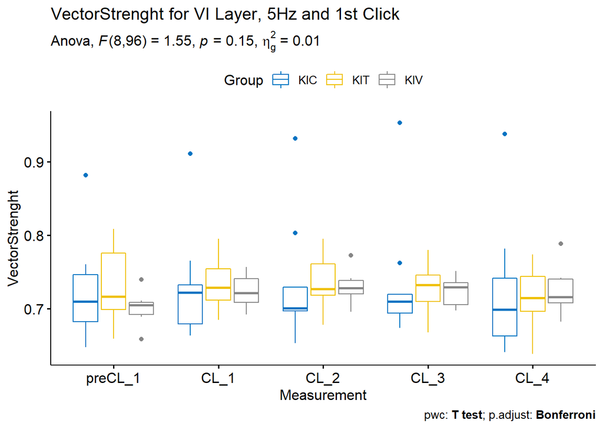

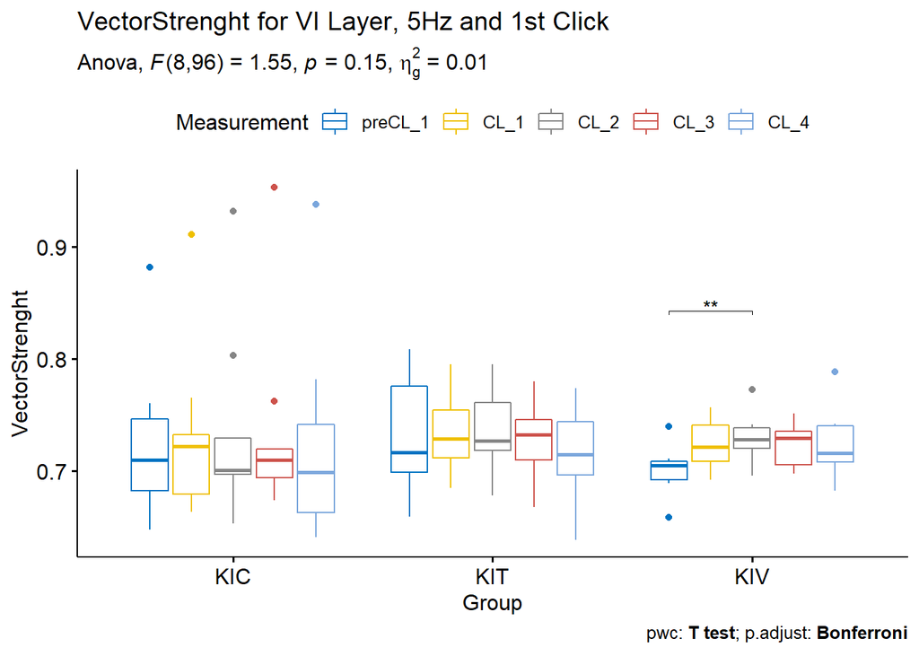